# Estudios de Informática, Multimedia y Telecomunicaciones

# Pràctica Mineria de Dades

Víctor Marmol

2023-06-27

# 1 El factors que produeixen un **hit** musical.

## 1.1 Introducció

La música ens rodeja i ara més que mai. Aquest fet és notable i les companyies privades ho saben, la música ha passat de ser un plaer personal a una de les industries més potents d’avui en dia. Però com podem convertir un gust musical personal en algun producte comercialitzable? Més enllà del merchandising, la solució que han trobat plataformes com Spotify és un sistema d’avaluació de cançons en que tota cançó es pot desglossar en paràmetres que es poden quantificar. A algunes persones els hi causa terror aquesta idea però podem arribar a conèixer molta informació musical amb aquests paràmetres numèrics i aquest projecte intenta extreure informació important d’aquestes dades que ens proporciona Spotify.

## 1.2 Primera part

### 1.2.1 Definició del problema

La idea principal d’aquest projecte de mineria de dades és estudiar quins paràmetres fan que una cançó sigui popular, i predefinir quines característiques ha de complir una pista d’àudio per a ser popular o, com a mínim, no ser una cançó desconeguda.

També voldríem mirar si depenent del gènere podríem trobar agrupacions de paràmetres que prediguin si una cançó serà popular dintre d’aquest gènere o no.

Pel camí, anirem explorant els paràmetres i intentarem arribar a conclusions tant del joc de dades com de conclusions que puguem anar traient d’aquest.

### 1.2.2 Descripció de l’origen del conjunt de dades

L’origen del conjunt de dades ha estat la pàgina recomanada www.kaggle.com.

En particular, utilitzarem aquest joc de dades de la plataforma Spotify sota una Open Database License (ODbL):

https://www.kaggle.com/datasets/maharshipandya/-spotify-tracks-dataset

Hem triat aquest joc de dades perquè complia amb els criteris mínims del joc de dades de la pràctica, estava prou net i no tenia un excés de valors buits o nuls, ens servia pel nostre objectiu i era interessant saber si, objectivament parlant, quanta part de la música és qüestió de gustos i quanta part és estudi de la industria musical.

### 1.2.3 Trobar el conjunt de dades

Cal descarregar el fitxer **.zip** i crear un directori: **Dades/spotify/** dins de la carpeta on es troba el projecte. Una vegada al directori spotify de la carpeta Dades enganxar el **.csv** dataset.

Una vegada llest ja podem carregar les dades d’aquesta pràctica:

```r
pathSpotify <- "Dades/spotify/dataset.csv"
Spotify <- read.csv(pathSpotify, row.names = NULL)
set.seed(3)
```

### 1.2.4 Anàlisi Exploratòria

Primer li farem un cop d’ull a l’estructura de les dades:

```r
str(Spotify)
```

```
## 'data.frame':    114000 obs. of  21 variables:
##  $ X               : int  0 1 2 3 4 5 6 7 8 9 ...
##  $ track_id        : chr  "5SuOikwiRyPMVoIQDJUgSV" "4qPNDBW1i3p13qLCt0Ki3A" "1iJBSr7s7jYXzM8EGcbK5b" "6lfxq3CG4xtTiEg7opyCyx" ...
##  $ artists         : chr  "Gen Hoshino" "Ben Woodward" "Ingrid Michaelson;ZAYN" "Kina Grannis" ...
##  $ album_name      : chr  "Comedy" "Ghost (Acoustic)" "To Begin Again" "Crazy Rich Asians (Original Motion Picture Soundtrack)" ...
##  $ track_name      : chr  "Comedy" "Ghost - Acoustic" "To Begin Again" "Can't Help Falling In Love" ...
##  $ popularity      : int  73 55 57 71 82 58 74 80 74 56 ...
##  $ duration_ms     : int  230666 149610 210826 201933 198853 214240 229400 242946 189613 205594 ...
##  $ explicit        : chr  "False" "False" "False" "False" ...
##  $ danceability    : num  0.676 0.42 0.438 0.266 0.618 0.688 0.407 0.703 0.625 0.442 ...
##  $ energy          : num  0.461 0.166 0.359 0.0596 0.443 0.481 0.147 0.444 0.414 0.632 ...
##  $ key             : int  1 1 0 0 2 6 2 11 0 1 ...
##  $ loudness        : num  -6.75 -17.23 -9.73 -18.52 -9.68 ...
##  $ mode            : int  0 1 1 1 1 1 1 1 1 1 ...
##  $ speechiness     : num  0.143 0.0763 0.0557 0.0363 0.0526 0.105 0.0355 0.0417 0.0369 0.0295 ...
##  $ acousticness    : num  0.0322 0.924 0.21 0.905 0.469 0.289 0.857 0.559 0.294 0.426 ...
##  $ instrumentalness: num  1.01e-06 5.56e-06 0.00 7.07e-05 0.00 0.00 2.89e-06 0.00 0.00 4.19e-03 ...
##  $ liveness        : num  0.358 0.101 0.117 0.132 0.0829 0.189 0.0913 0.0973 0.151 0.0735 ...
##  $ valence         : num  0.715 0.267 0.12 0.143 0.167 0.666 0.0765 0.712 0.669 0.196 ...
##  $ tempo           : num  87.9 77.5 76.3 181.7 119.9 ...
##  $ time_signature  : int  4 4 4 3 4 4 3 4 4 4 ...
##  $ track_genre     : chr  "acoustic" "acoustic" "acoustic" "acoustic" ...
```

Observem que és un data frame de 114.000 observacions amb 21 variables. Cal destacar que tenim 15 columnes numèriques, 5 de caràcters i una binària.

Veiem què és cadascuna d’elles:

- *track_id*: la identificació que utilitza Spotify per a la cançó.
- *artist*: el nom dels artistes que col·laboren en la cançó.
- *album_name*: nom de l’àlbum en el que es troba la cançó.
- *track_name*: nom de la cançó.
- *popularity*: popularitat. És un valor entre l’1 i el 100 calculat per la xarxa neuronal d’Spotify. Els càlculs no els sabem concretament però és el número que utilitza el programa per a recomanar certs artistes i/o cançons.
- *duration_ms*: duració en milisegons.
- *explicit*: si la cançó té lletra explícita o no.
- *danceability*: paràmetre que calcula Spotify per a considerar si una cançó es pot ballar o no. Siguent 1 que es pot i 0 que no.
- *energy*: és una mesura del 0 a l’1 que representa la intensitat i la activitat de la cançó.
- *key*: indica en quina clau està la cançó.
- *loudness*: la mesura del volum en decibels (dB).
- *mode*: indica en quina modalitat es troba la cançó (major o menor).
- *speechiness*: Indica la presència de paraules parlades en una pista. Els valors més propers a l’1 tenen menys melodia i més discurs. Es considera que per sobre de 0.66 aquest paràmetre descriu pistes que són exclusivament paraules parlades com podcasts o àudiollibres, entre 0.66 i 0.33 tenim pistes que tenen música i discursos i, per últim, les pistes per sota de 0.33 representaran música i pistes on no es senti gent parlar.
- *acousticness*: un paràmetre per a dir si la cançó és acústica o no, 1 representa que és amb alta probabilitat acústica.
- *instrumentalness*: prediu si una cançó conté veu o no. Si aquest paràmetre s’apropa a 1 tindrem menys veus. Per exemple el rap tindrà l’**instrumentalness** baix i la música instrumental el tindrà alt.
- *liveness*: Detecta la presència de l’audiència a l’àudio. Quant més alt més probable que ens trobem amb una gravació d’un directe.
- *valence*: Detecta la positivitat d’una pista. Quant més proper a l’1 l’àudio sonarà més alegre o positiu i quant més baix més trist o enfadat.
- *tempo*: El tempo de la cançó en batecs per minut (BPM).
- *time_signature*: és una estimació de les pulsacions per cada compàs. Varia de 3 a 7 i indica si és 3/4 fins a 7/4.
- *track_genre*: és el gènere al qual pertany la pista d’àudio.

El primer pas, com sempre, és netejar les nostres dades per a poder començar a treballar amb elles. Tot i que les haguem obtingut de kaggle.com i sembli que estan llestes per a treballar, sempre és important comprovar-ho.

Veiem si hi ha valors nuls:

```r
if(sum(colSums(is.na(Spotify)))==0){
  print("No hi ha valors nuls")
} else {
  print("Si hi ha valors nuls")
}
```

```
## [1] "No hi ha valors nuls"
```

Sembla que no hi ha valors nuls. Veiem els valors en blanc:

```r
if(sum(colSums(Spotify==""))==0){
  print("No hi ha valors en blanc")
} else {
  print("Si hi ha valors en blanc")
}
```

```
## [1] "Si hi ha valors en blanc"
```

Per tant, si que tenim valors en blanc, anem a especificar on es troben:

```r
names(which(colSums(Spotify=="")!=0))
```

```
## [1] "artists"    "album_name" "track_name"
```

```r
sum(Spotify$artists=="")
```

```
## [1] 1
```

```r
sum(Spotify$album_name=="")
```

```
## [1] 1
```

```r
sum(Spotify$track_name=="")
```

```
## [1] 1
```

Veiem que només tenim un error a cada camp, mirem si coincideixen i si és així quin cas és:

```r
which(Spotify$artists=="")
```

```
## [1] 65901
```

```r
which(Spotify$album_name=="")
```

```
## [1] 65901
```

```r
which(Spotify$track_name=="")
```

```
## [1] 65901
```

```r
Spotify[65901,]
```

```
##           X               track_id artists album_name track_name popularity
## 65901 65900 1kR4gIb7nGxHPI3D2ifs59                                        0
##       duration_ms explicit danceability energy key loudness mode speechiness
## 65901           0    False        0.501  0.583   7    -9.46    0      0.0605
##       acousticness instrumentalness liveness valence   tempo time_signature
## 65901         0.69          0.00396   0.0747   0.734 138.391              4
##       track_genre
## 65901       k-pop
```

Observem que no tenim artista, ni nom de l’àlbum, ni nom de la pista però, abans d’eliminar aquest registre hem de considerar si podem recuperar la informació amb el **track_id**.

De manera que hem de cercar: https://open.spotify.com/track/1kR4gIb7nGxHPI3D2ifs59. I veiem que la cançó no es pot reproduir i que el millor que podem fer és eliminar el registre per no tenir dades esbiaixades.

```r
Spotify <- Spotify[-65901,]
```

Fem la comprovació de que no tenim registres en blanc:

```r
if(sum(colSums(Spotify==""))==0){
  print("No hi ha valors en blanc")
} else {
  print("Si hi ha valors en blanc")
}
```

```
## [1] "No hi ha valors en blanc"
```

És hora de crear histogrames i altres representacions gràfiques de les dades per a veure amb què estem treballant:

```r
if(!require('ggplot2')) install.packages('ggplot2'); library('ggplot2')
if(!require('Rmisc')) install.packages('Rmisc'); library('Rmisc')
if(!require('dplyr')) install.packages('dplyr'); library('dplyr')
if(!require('xfun')) install.packages('xfun'); library('xfun')
if(!require('gridExtra')) install.packages('gridExtra'); library('gridExtra')
```

Començarem amb la popularitat de les pistes d’àudio:

```r
summary(Spotify$popularity)
```

```
##    Min. 1st Qu.  Median    Mean 3rd Qu.    Max.
##    0.00   17.00   35.00   33.24   50.00  100.00
```

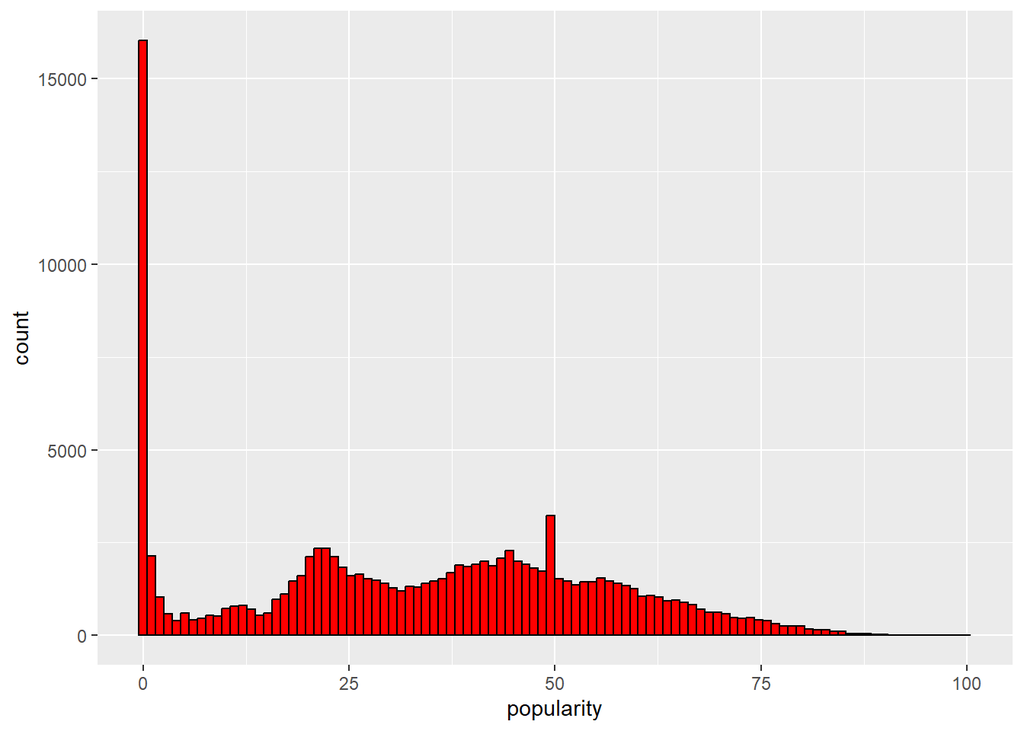

```r
histpop <- ggplot(Spotify, aes(x = !!rlang::sym("popularity")))+
  geom_histogram(bins=100, fill = "red", color="black")
histpop
```

Veiem la resta de paràmetres. Comencem amb els numèrics:

```r
paràmetres <- c(
  "duration_ms",
  "danceability",
  "energy",
  "loudness",
  "speechiness",
  "acousticness",
  "instrumentalness",
  "liveness",
  "valence",
  "tempo"
)

histograma <- function(variable) {
  ggplot(Spotify, aes(x = !!rlang::sym(variable))) +
    geom_histogram(bins = 30, fill = "red", color = "black") +
    labs(title = variable) +
    theme_minimal()
}
summarylapply <- function(variable){
  cat("summary de",variable,":\n")
  print(summary(Spotify[[variable]]))
}

histogrames <- lapply(paràmetres, histograma)
summaries <- lapply(paràmetres, summarylapply)
```

```
## summary de duration_ms :
##    Min. 1st Qu.  Median    Mean 3rd Qu.    Max.
##    8586  174066  212906  228031  261506 5237295
## summary de danceability :
##    Min. 1st Qu.  Median    Mean 3rd Qu.    Max.
##  0.0000  0.4560  0.5800  0.5668  0.6950  0.9850
## summary de energy :
##    Min. 1st Qu.  Median    Mean 3rd Qu.    Max.
##  0.0000  0.4720  0.6850  0.6414  0.8540  1.0000
## summary de loudness :
##    Min. 1st Qu.  Median    Mean 3rd Qu.    Max.
## -49.531 -10.013  -7.004  -8.259  -5.003   4.532
## summary de speechiness :
##    Min. 1st Qu.  Median    Mean 3rd Qu.    Max.
## 0.00000 0.03590 0.04890 0.08465 0.08450 0.96500
## summary de acousticness :
##    Min. 1st Qu.  Median    Mean 3rd Qu.    Max.
##  0.0000  0.0169  0.1690  0.3149  0.5975  0.9960
## summary de instrumentalness :
##      Min.   1st Qu.    Median      Mean   3rd Qu.      Max.
## 0.0000000 0.0000000 0.0000416 0.1560509 0.0490000 1.0000000
## summary de liveness :
##    Min. 1st Qu.  Median    Mean 3rd Qu.    Max.
##  0.0000  0.0980  0.1320  0.2136  0.2730  1.0000
## summary de valence :
##    Min. 1st Qu.  Median    Mean 3rd Qu.    Max.
##  0.0000  0.2600  0.4640  0.4741  0.6830  0.9950
## summary de tempo :
##    Min. 1st Qu.  Median    Mean 3rd Qu.    Max.
##    0.00   99.22  122.02  122.15  140.07  243.37
```

```r
summaries[1]
```

```
## [[1]]
##    Min. 1st Qu.  Median    Mean 3rd Qu.    Max.
##    8586  174066  212906  228031  261506 5237295
```

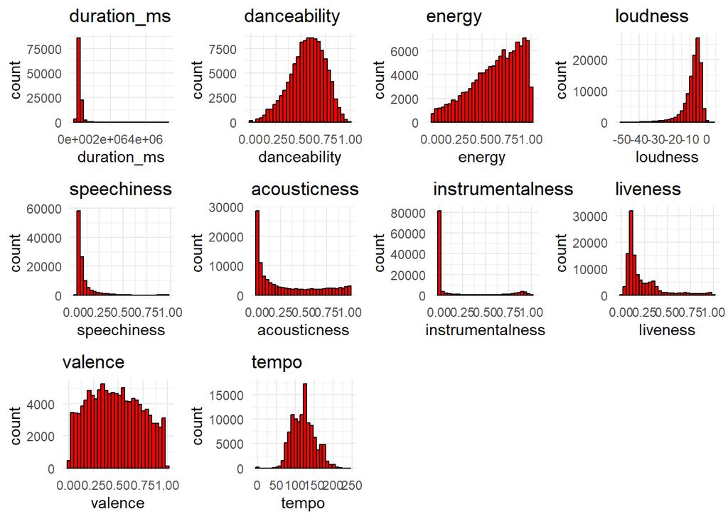

```r
grid.arrange(grobs = histogrames, nrow = 3)
```

Observem que pel que fa a la dançabilitat, l’energia, el volum, el paràmetre liveness, la valència i el tempo no són distribucions normals però no dona la sensació de que ens donaran problemes a l’hora de tenir molta correlació. D’altra banda, si que podríem tenir aquest problema amb la durada, l’speechiness, l’acousticness i l’instrumentalness. Mirarem si hi ha alguna manera d’evitar aquest problema.

Per exemple amb la durada, podem veure a l’histograma que la variable sembla que tingui una distribució log-normal i, per tant, li farem el logaritme i la normalitzarem:

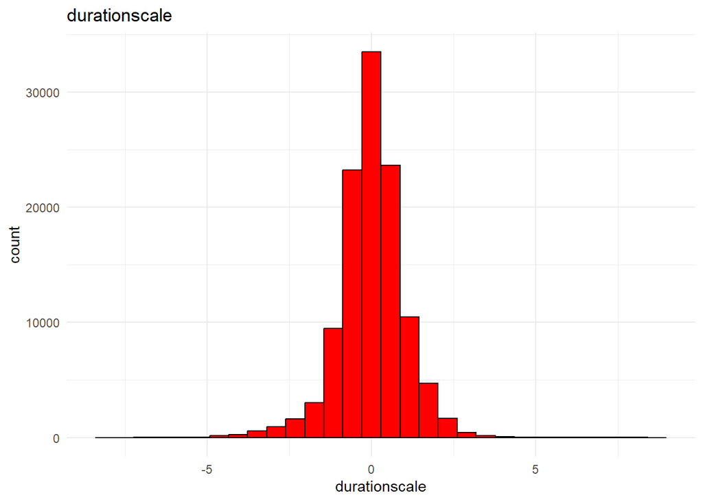

```r
Spotify$durationscale <- as.vector(scale(log(Spotify$duration_ms)))

histograma("durationscale")
```

Amb les altres tres si que sembla que tenim més problema donat que no podem deduir una distribució a simple vista. Avançarem amb la pràctica i actuarem si sorgeix algun problema.

Considerem ara les variables que no són numèriques. Els noms dels artistes, la identificació de la pista, el nom de l’àudio o de l’àlbum a un nivell de mineria de dades només ens interessa per a explicar els resultats, no per a una anàlisi tècnica i els deixarem de banda de moment. La resta de variables si que ens interessen:

```r
explicittaula <- table(Spotify$explicit)
explicittaula
```

```
##
##  False   True
## 104252   9747
```

```r
prop.table(explicittaula)
```

```
##
##      False       True
## 0.91449925 0.08550075
```

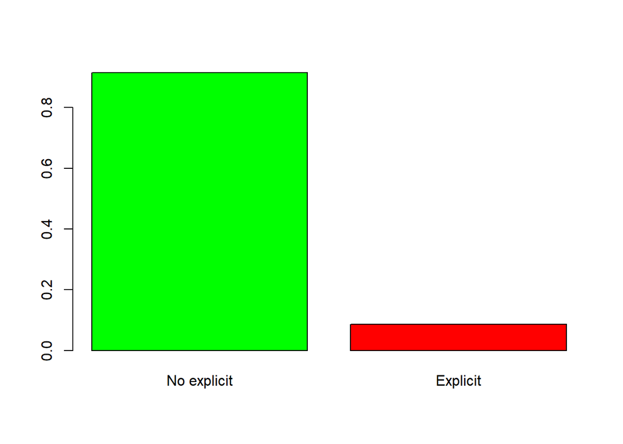

```r
barplot(prop.table(explicittaula),col = c("green","red"), names.arg = c("No explicit","Explicit"))
```

Com podem veure la majoria de les lletres no són explícites. Veiem com afecta aquesta característica a la popularitat.

El primer que farem serà discretitzar la popularitat en intervals de 10:

```r
Spotify$popularity10 <- cut(Spotify$popularity, breaks = seq(0,100,by = 10))

Spotify$popularity4 <- cut(Spotify$popularity, breaks = seq(0,100,by = 25))

Spotify$popularity4[Spotify$popularity == 0] <- "(0,25]"

levels(Spotify$popularity4) <- c("[0,25]", "(25,50]", "(50,75]", "(75,100]")
```

Ara calcularem les proporcions, però no amb **prop.table** volem veure la proporció respecte al número de cançons que tenim. Així, podem comparar si és millor crear una cançó amb lletres explícites o no:

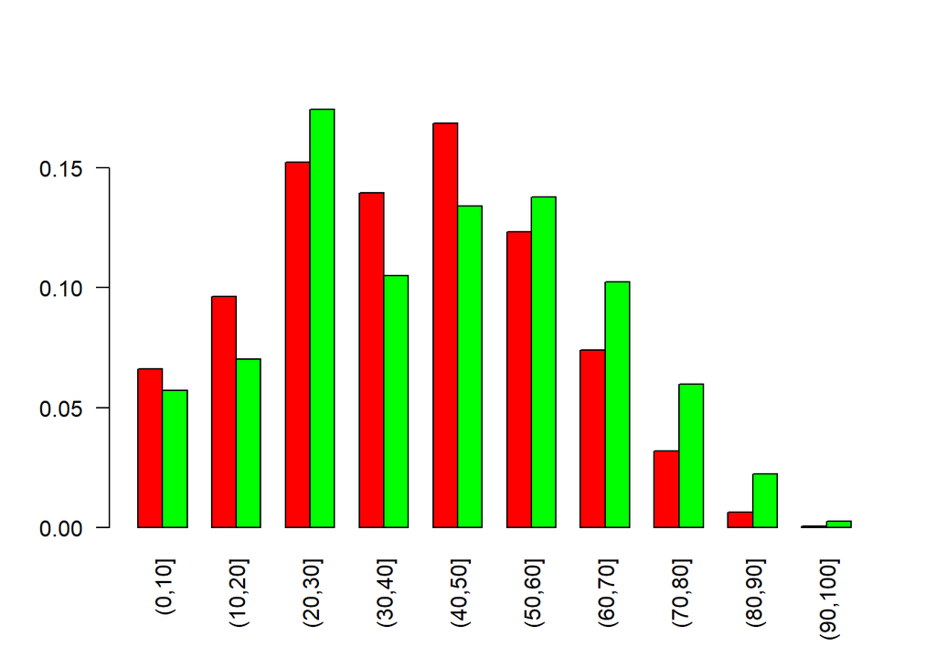

```r
counts <- table(Spotify$explicit, Spotify$popularity10)
propfals <- counts[1,]/explicittaula[1]
proptrue <- counts[2,]/explicittaula[2]
propexpl <- data.frame(propfals,proptrue)
row.names(propexpl) <- c("(0,10]", "(10,20]", "(20,30]", "(30,40]", "(40,50]", "(50,60]", "(60,70]", "(70,80]", "(80,90]", "(90,100]")

#prop.table(counts)
barplot(t(propexpl), beside = TRUE, col=c("red","green"), las=2)
```

Ara bé, no caiguem en conclusions precipitades, caldria mirar si sobre algun tipus de població aquestes cançons amb lletres explícites són més populars. No estaria malament estudiar sobre quina franja d’edat aquestes cançons tenen més èxit, en quines regions són més populars (Al Canadà és complicat escoltar reggaeton que és un gènere que utilitza un llenguatge explícit i a Espanya és molt habitual) o inclús si el nivell adquisitiu pot tenir res a veure.

Per continuar, estudiarem tres paràmetres relacionats amb la melodia i el ritme. Últimament no és estrany escoltar que “tota la música d’avui en dia sona igual” o que “ja tot està inventat”.

Anem a veure si aquestes apreciacions són fruit de la falta de comprensió o si realment podem demostrar amb dades que aquestes queixes són fonamentades.

Primer estudiem la clau:

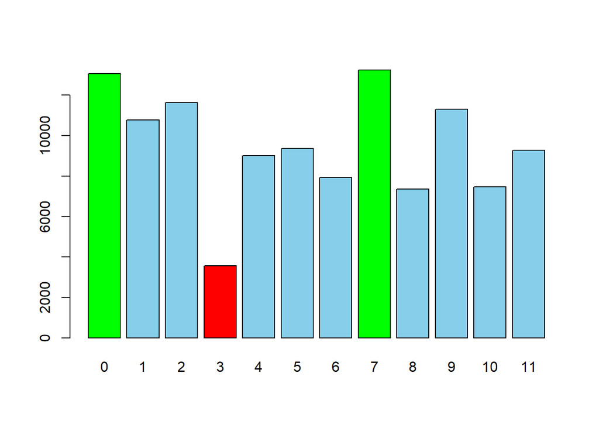

```r
barplot(table(Spotify$key), col=c("green",
                                   rep("skyblue",2),
                                   "red",
                                   rep("skyblue",3),
                                   "green",
                                   rep("skyblue",4)))
```

Clarament hi ha dues claus preferides i una que no agrada gens. Les dues preferides són Do i Sol i la que no tenim és el Re sostingut. Tot i que hauríem de consultar a algun expert amb més idea musical que l’autor d’aquesta pràctica, les escales de Do i de Sol són les primeres en ensenyar-se al conservatori, en particular les majors, i a on la majoria de gent està més còmode. D’altra banda, l’escala de Re Sostingut si que té moltes notes que són sostinguts o bemolls i no és tan natural d’escoltar.

Veiem el mode de les cançons:

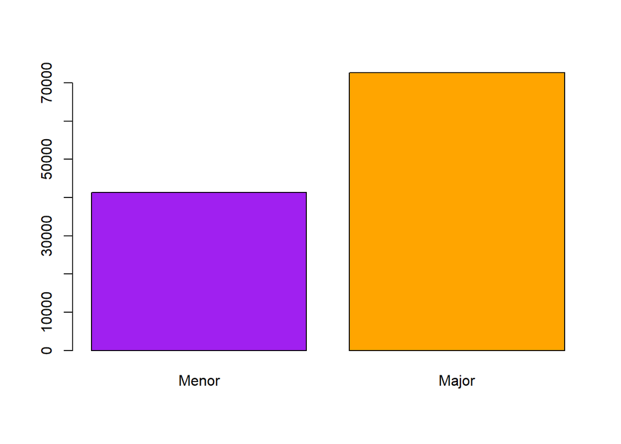

```r
barplot(table(Spotify$mode), col = c("purple","orange"), names.arg = c("Menor","Major"))
```

Ara que tenim la clau i la tonalitat. Veiem quines són les escales més utilitzades:

```r
table(Spotify$mode, Spotify$key)
```

```
##
##         0     1     2     3     4     5     6     7     8     9    10    11
##   0  2864  3595  2582  1344  4733  4024  3825  3095  1918  4453  3737  5148
##   1 10197  7177  9062  2226  4275  5344  4096 10149  5442  6860  3719  4134
```

```r
prop.table(table(Spotify$mode, Spotify$key))
```

```
##
##              0          1          2          3          4          5
##   0 0.02512303 0.03153536 0.02264932 0.01178958 0.04151791 0.03529856
##   1 0.08944815 0.06295669 0.07949193 0.01952649 0.03750033 0.04687760
##
##              6          7          8          9         10         11
##   0 0.03355293 0.02714936 0.01682471 0.03906175 0.03278099 0.04515829
##   1 0.03593014 0.08902710 0.04773726 0.06017597 0.03262309 0.03626348
```

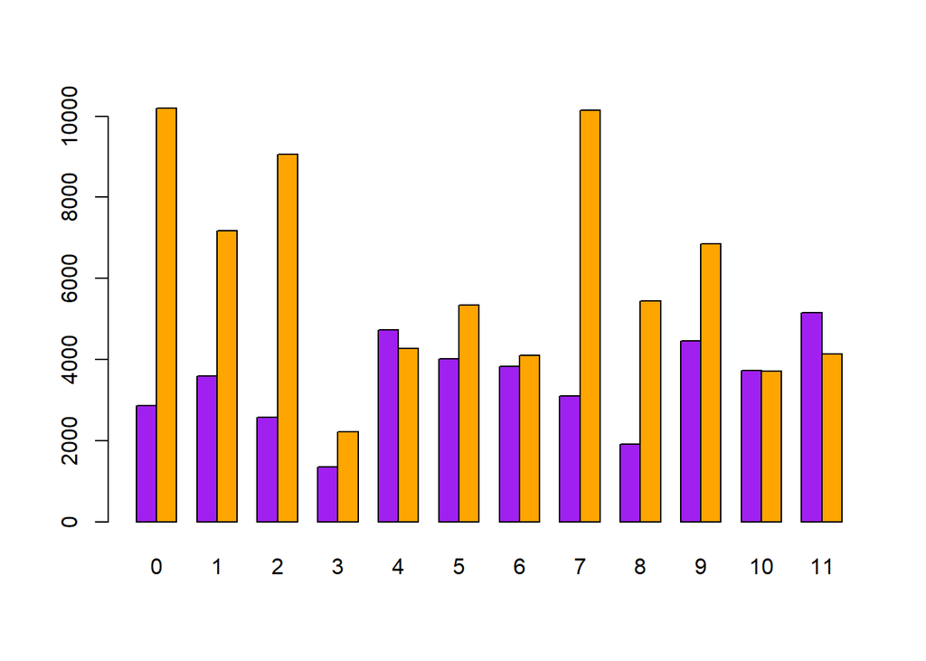

```r
barplot(table(Spotify$mode, Spotify$key),beside=TRUE, col = c("purple","orange"))
```

Per tant, corroborem que les escales més utilitzades són Do major i Sol major. La menys utilitzada és Re sostingut menor i l’escala menor més utilitzada és Si menor.

Podem afirmar que les escales de Do Major i Sol Major s’utilitzen gairebé amb la mateixa proporció i que gairebé una de cada cinc cançons (approx. 18%) que trobem en aquesta llista estan en aquestes dues escales.

Caldria consultar a un expert musical si volguéssim més concreció i un discurs més tècnic però si que sembla un percentatge molt gran i ens permet comprendre una mica aquesta protesta de que “avui en dia tot sona igual”.

Potser trobem més heterogeneïtat en el ritme que no pas en la melodia, mirem-ho:

```r
prop.table(table(Spotify$time_signature))
```

```
##
##           0           1           3           4           5
## 0.001429837 0.008535163 0.080658602 0.893358714 0.016017684
```

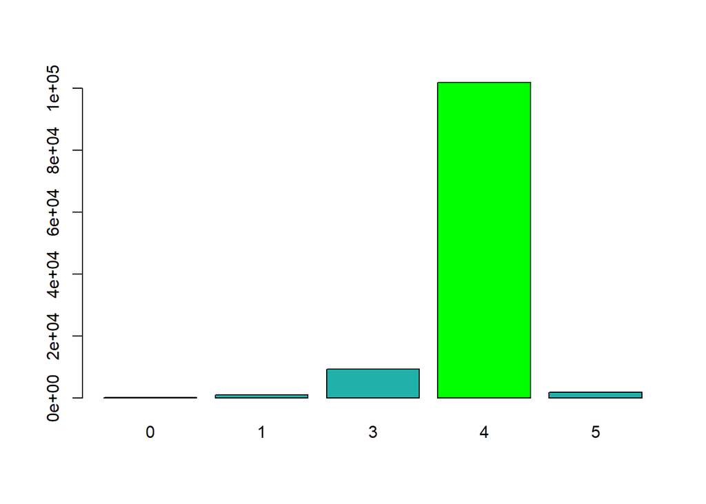

```r
barplot(table(Spotify$time_signature),col=c(rep("lightseagreen",3),"green","lightseagreen"))
```

Més del 89% de les cançons estan en 4/4. Per tant, no tenim més heterogeneïtat que amb la melodia.

Aquestes dades tan extremes fan pensar que aquesta llista potser està esbiaixada i que té més cançons d’algun gènere en concret que no pas d’altres.

Estudiarem ara aquest últim paràmetre:

```r
#table(Spotify$track_genre)
head(table(Spotify$track_genre))
```

```
##
##    acoustic    afrobeat    alt-rock alternative     ambient       anime
##        1000        1000        1000        1000        1000        1000
```

Ens trobem amb que tenim 1000 cançons per gènere. Aquest fet deu ser degut per la construcció del joc de dades.

Ja sabem que la majoria de cançons estan en 4/4, però quins generes són els que utilitzen la resta de compassos? És el 4/4 un ritme d’occident i tenim un esbiaixament de les dades perquè les cançons estan occidentalitzades? Veiem-ho!

```r
Spotify04 <- subset(Spotify, Spotify$time_signature == 0)
table(Spotify04$track_genre)
```

```
##
##    alt-rock     ambient      disney      guitar     iranian        jazz
##           1           3           1           4           4           1
##       opera       piano     romance  show-tunes       sleep     turkish
##           3           1           1           2         138           1
## world-music
##           3
```

És interessant comprovar que la majoria de cançons en 6/4 són del gènere per a dormir.

D’altra banda el compàs 7/4:

```r
Spotify14 <- subset(Spotify, Spotify$time_signature == 1)
head(sort(table(Spotify14$track_genre), decreasing = TRUE),10)
```

```
##
##     sleep    comedy classical   ambient grindcore      folk   iranian     opera
##        57        56        42        39        36        30        29        29
##   romance     malay
##        29        27
```

Tornem a obtenir música per a dormir però és interessant veure com la música clàssica, el folk, la iraniana i l’òpera surten significativament. Aquest fet és important i reforça la hipòtesi de que el 4/4 és un ritme modern i occidental. Comprovem aquest fet amb el 3/4:

```r
Spotify34 <- subset(Spotify, Spotify$time_signature == 3)
head(sort(table(Spotify34$track_genre), decreasing = TRUE),10)
```

```
##
##    comedy   romance     opera   ambient     sleep   new-age   iranian classical
##       318       278       268       264       259       238       234       226
##     piano    disney
##       204       191
```

Tornem a verificar la hipòtesi donat que tornem a trobar música iraniana, òpera, clàssica i de piano.

```r
Spotify54 <- subset(Spotify, Spotify$time_signature == 5)
head(sort(table(Spotify54$track_genre), decreasing = TRUE),10)
```

```
##
##   j-dance     sleep dancehall    comedy      funk   iranian   romance       idm
##       159       114       110        87        84        65        63        49
##   ambient classical
##        46        41
```

I, definitivament podem parlar d’una llista prou occidentalitzada. El fet que en aquest compàs ens surti dancehall i funk que son ritmes no occidentals corroboren la hipòtesi amb que treballàvem.

Estudiem les correlacions:

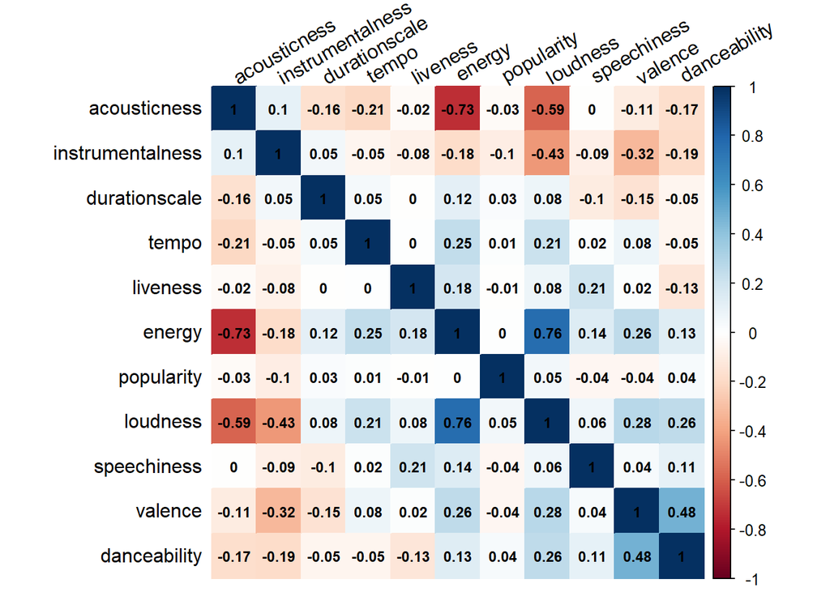

```r
if(!require("dplyr")) install.packages("dplyr"); library("dplyr")
if(!require("corrplot")) install.packages("corrplot"); library("corrplot")
n <- c(
  "popularity",
  "durationscale",
  "danceability",
  "energy",
  "loudness",
  "speechiness",
  "acousticness",
  "instrumentalness",
  "liveness",
  "valence",
  "tempo"
)

factors <- Spotify %>% select(all_of(n))

res <- cor(factors)

corrplot(res, method="color", tl.col="black", tl.srt=30, order = "AOE",
number.cex=0.75, sig.level = 0.01, addCoef.col = "black")
```

Aquesta matriu de correlacions és molt interessant.

En general ens ha de preocupar la correlació negativa entre l’energia i si una cançó és acústica o no, el soroll i si una cançó és acústica o no i la correlació positiva entre l’energia i lo sorollosa que és una cançó. La resta són correlacions prou baixes que no ens haurien de donar cap problema.

Donat que la nostra intenció és dur a terme un procés de PCA o SVD, deixarem les variables amb correlació alta, tenint en compte que podem corregir aquesta decisió si els resultats posteriors ho demanen.

### 1.2.5 SVD

El següent pas és reduir la dimensionalitat i ho farem amb SVD. És cert que el cost computacional d’aquest mètode és pitjor que el de PCA però hem d’entendre que les nostres dades no són normals, no estan escalades i tenim una gran presència d’outliers en alguns casos. Per tant, la SVD és millor en el nostre cas.

Primer hem de trobar la descomposició i R té la instrucció **svd()**:

```r
SVD <- svd(res)

round(SVD$d,1)
```

```
##  [1] 2.9 1.5 1.3 1.0 0.9 0.9 0.8 0.7 0.4 0.3 0.1
```

```r
round(SVD$u,1)
```

```
##       [,1] [,2] [,3] [,4] [,5] [,6] [,7] [,8] [,9] [,10] [,11]
##  [1,]  0.0  0.0 -0.2 -0.9 -0.1 -0.4  0.1 -0.2 -0.1   0.0   0.0
##  [2,] -0.1  0.4 -0.2 -0.1  0.5  0.1 -0.7  0.0 -0.1   0.0   0.0
##  [3,] -0.2 -0.5 -0.3  0.1  0.3 -0.3 -0.2 -0.2  0.6  -0.1   0.2
##  [4,] -0.5  0.2  0.1  0.1  0.1 -0.1  0.2 -0.1 -0.2  -0.2   0.7
##  [5,] -0.5  0.1  0.0 -0.1  0.0  0.1  0.1  0.2  0.1  -0.6  -0.5
##  [6,] -0.1 -0.2  0.6  0.1  0.1 -0.6 -0.3  0.4 -0.2   0.0  -0.1
##  [7,]  0.4 -0.3  0.1 -0.1 -0.1  0.2 -0.3  0.0 -0.1  -0.7   0.3
##  [8,]  0.3  0.3 -0.1  0.4  0.1 -0.5  0.2 -0.5 -0.1  -0.3  -0.2
##  [9,] -0.1  0.1  0.7 -0.2  0.1  0.3  0.0 -0.5  0.3   0.0  -0.1
## [10,] -0.3 -0.5 -0.1  0.1 -0.1  0.2 -0.2 -0.4 -0.6   0.1  -0.2
## [11,] -0.2  0.2  0.0  0.1 -0.8 -0.1 -0.5 -0.1  0.2   0.0   0.0
```

```r
#round(SVD$v,1)

round(SVD$u,1)-round(SVD$v,1)
```

```
##       [,1] [,2] [,3] [,4] [,5] [,6] [,7] [,8] [,9] [,10] [,11]
##  [1,]    0    0    0    0    0    0    0    0    0     0     0
##  [2,]    0    0    0    0    0    0    0    0    0     0     0
##  [3,]    0    0    0    0    0    0    0    0    0     0     0
##  [4,]    0    0    0    0    0    0    0    0    0     0     0
##  [5,]    0    0    0    0    0    0    0    0    0     0     0
##  [6,]    0    0    0    0    0    0    0    0    0     0     0
##  [7,]    0    0    0    0    0    0    0    0    0     0     0
##  [8,]    0    0    0    0    0    0    0    0    0     0     0
##  [9,]    0    0    0    0    0    0    0    0    0     0     0
## [10,]    0    0    0    0    0    0    0    0    0     0     0
## [11,]    0    0    0    0    0    0    0    0    0     0     0
```

Ens hem quedat amb les tres matrius: la diagonal (d) amb els valors propis i les matrius de vectors esquerra i dreta (u,v) que ens expliquen el pes i la importància en la variació del resultat de les variables. Cal fixar-se en que com que la matriu és simètrica u i v són iguals.

Voldríem reduir la dimensionalitat. Pel criteri de Guttman-Kaiser podem triar els valors que siguin més grans que 1. De manera que ens quedarien els següents valors:

```r
subset(round(SVD$d,1),round(SVD$d,1)>1)
```

```
## [1] 2.9 1.5 1.3
```

De tota manera també aplicarem el test de Cattell que consisteix a representar gràficament els valors singulars:

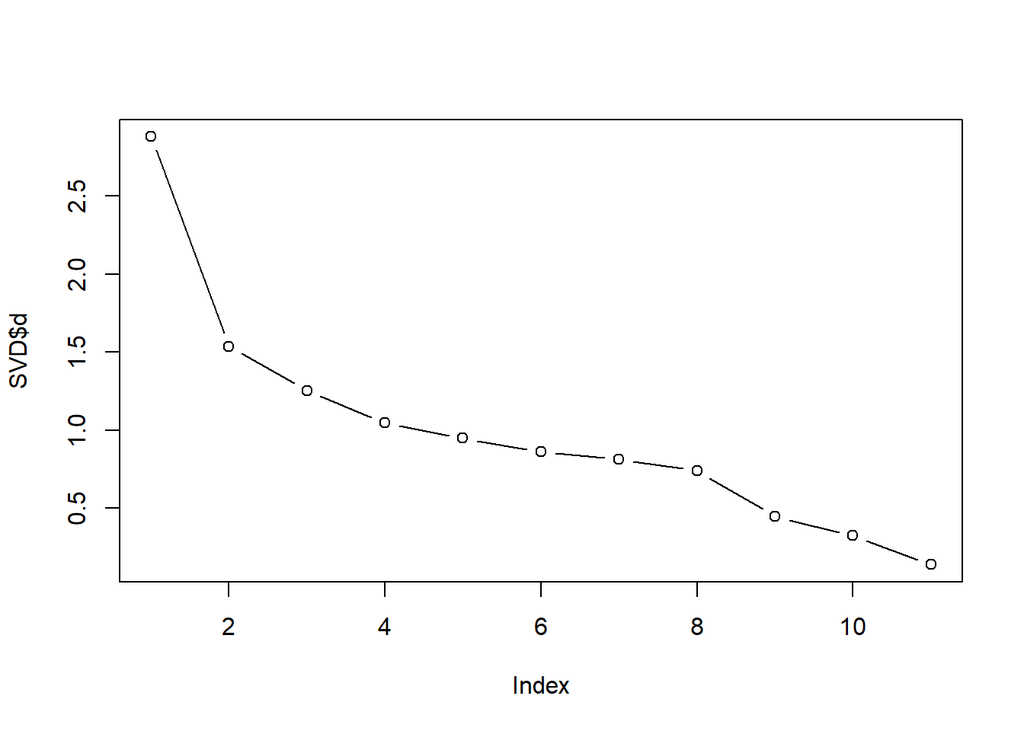

```r
plot(SVD$d, type = "b")
```

El que busquem amb aquest gràfic és una caiguda brusca dels valors però en aquest cas la tindríem en 2 valors.

Triarem llavors 3 donat que obtindrem més informació, tot i que, com sempre, cal recordar aquesta decisió i si, en un futur, se’ns presenten problemes hem de tenir en compte la decisió que acabem de prendre.

Per tant,

```r
ValorsReduits <- diag(c(subset(SVD$d,round(SVD$d,1)>1),rep(0,8)))
#ValorsReduits
SVDred <- SVD$u%*%ValorsReduits%*%t(SVD$v)
SVDred
```

```
##               [,1]        [,2]        [,3]       [,4]       [,5]        [,6]
##  [1,]  0.034742926  0.05744797  0.06446583  0.0343898  0.0556768 -0.11403554
##  [2,]  0.057447968  0.34964660 -0.20580709  0.2065754  0.1340329 -0.25600793
##  [3,]  0.064465825 -0.20580709  0.60825716  0.1557486  0.3202004 -0.01244597
##  [4,]  0.034389803  0.20657539  0.15574858  0.8427132  0.7815662  0.15185566
##  [5,]  0.055676803  0.13403289  0.32020042  0.7815662  0.7795397  0.10254932
##  [6,] -0.114035543 -0.25600793 -0.01244597  0.1518557  0.1025493  0.52072279
##  [7,] -0.070518503 -0.29962836 -0.12355455 -0.7454467 -0.6963388  0.04001113
##  [8,] -0.006952133  0.17821706 -0.40334365 -0.3077467 -0.3814683 -0.20161306
##  [9,] -0.125145959 -0.11585905 -0.22838116  0.2318217  0.1086989  0.51426237
## [10,]  0.035915679 -0.25904107  0.60407988  0.2322165  0.3788890  0.12858952
## [11,]  0.024890003  0.18369960 -0.03245243  0.3600719  0.3084226 -0.01316713
##              [,7]         [,8]        [,9]       [,10]       [,11]
##  [1,] -0.07051850 -0.006952133 -0.12514596  0.03591568  0.02489000
##  [2,] -0.29962836  0.178217060 -0.11585905 -0.25904107  0.18369960
##  [3,] -0.12355455 -0.403343651 -0.22838116  0.60407988 -0.03245243
##  [4,] -0.74544667 -0.307746660  0.23182166  0.23221649  0.36007188
##  [5,] -0.69633881 -0.381468322  0.10869892  0.37888904  0.30842260
##  [6,]  0.04001113 -0.201613062  0.51426237  0.12858952 -0.01316713
##  [7,]  0.72242661  0.202825388 -0.04961091 -0.14661693 -0.35131374
##  [8,]  0.20282539  0.378716717 -0.08001981 -0.46407764 -0.04278633
##  [9,] -0.04961091 -0.080019815  0.61003880 -0.08230172  0.06682639
## [10,] -0.14661693 -0.464077636 -0.08230172  0.63977277 -0.01847383
## [11,] -0.35131374 -0.042786330  0.06682639 -0.01847383  0.18548378
```

És molt destacable que aquesta matriu, per exemple, a l’últim terme de la diagonal té un valor massa proper al zero. Dona que pensar que potser hem reduït massa les dimensions. Comprovem-ho amb la norma de Frobenius per a matrius:

```r
frobnorm <- sqrt(sum((res-SVDred)^2))
frobnorm
```

```
## [1] 2.069032
```

Dista prou de 0, tornarem enrere i utilitzarem un altre criteri de selecció de valors. Aquest mètode consisteix a prendre suficients valors singulars com per a que la suma dels quadrats d’aquests s’aproximi al 90% de la suma dels quadrats de tots els valors singulars. En el nostre cas, veiem que:

```r
valors90 <- 0.9*sum(round(SVD$d,1)^2)
valors90
```

```
## [1] 14.724
```

```r
valorsnous <- subset(round(SVD$d,1),round(SVD$d,1)>0.8)
sum(valorsnous^2)
```

```
## [1] 14.97
```

```r
valors90 - sum(valorsnous^2)
```

```
## [1] -0.246
```

Només per entendre la diferència amb els anteriors valors triats:

```r
valors90-sum(subset(round(SVD$d,1),round(SVD$d,1)>1)^2)
```

```
## [1] 2.374
```

El valor és prou més alt.

Tornem a dur a terme la reducció de la dimensionalitat:

```r
ValorsReduits <- diag(c(subset(SVD$d,round(SVD$d,1)>0.8),rep(0,5)))

SVDred <- SVD$u%*%ValorsReduits%*%t(SVD$v)
SVDred
```

```
##              [,1]         [,2]        [,3]        [,4]        [,5]        [,6]
##  [1,]  0.95744395  0.063564700  0.04937517 -0.03306338  0.07238904  0.01464227
##  [2,]  0.06356470  0.594177793 -0.12247678  0.21623856  0.15918948 -0.26678765
##  [3,]  0.04937517 -0.122476784  0.77304035  0.19596661  0.29027100  0.17959840
##  [4,] -0.03306338  0.216238557  0.19596661  0.85741059  0.77136672  0.19389714
##  [5,]  0.07238904  0.159189477  0.29027100  0.77136672  0.79313414  0.04806350
##  [6,]  0.01464227 -0.266787647  0.17959840  0.19389714  0.04806350  0.82769009
##  [7,] -0.01246627 -0.322611577 -0.20690214 -0.77016434 -0.67678550 -0.05914565
##  [8,] -0.19262137  0.136781978 -0.20831535 -0.24191652 -0.44670632  0.07393067
##  [9,] -0.06856307 -0.004927767 -0.29591059  0.20491067  0.15034158  0.36498372
## [10,] -0.12422781 -0.287484343  0.55667732  0.23212911  0.38460443  0.04833031
## [11,]  0.03545279 -0.201963554 -0.19206688  0.33605834  0.27690821 -0.03383873
##                [,7]        [,8]          [,9]       [,10]       [,11]
##  [1,] -0.0124662717 -0.19262137 -0.0685630701 -0.12422781  0.03545279
##  [2,] -0.3226115769  0.13678198 -0.0049277674 -0.28748434 -0.20196355
##  [3,] -0.2069021448 -0.20831535 -0.2959105947  0.55667732 -0.19206688
##  [4,] -0.7701643428 -0.24191652  0.2049106736  0.23212911  0.33605834
##  [5,] -0.6767855006 -0.44670632  0.1503415806  0.38460443  0.27690821
##  [6,] -0.0591456490  0.07393067  0.3649837178  0.04833031 -0.03383873
##  [7,]  0.7690200320  0.08246921  0.0004476177 -0.13182582 -0.29856825
##  [8,]  0.0824692071  0.73369165 -0.2673166595 -0.48884894 -0.02353120
##  [9,]  0.0004476177 -0.26731666  0.7434974201 -0.07331370 -0.08562418
## [10,] -0.1318258189 -0.48884894 -0.0733136995  0.68279471  0.03120800
## [11,] -0.2985682537 -0.02353120 -0.0856241820  0.03120800  0.79986179
```

Observem que el valor que abans ens havia fet dubtar ara dista més del zero. Considerarem que aquesta reducció és valida i buscarem quines són les variables que afecten més a la popularitat de les cançons.

Recordem que el primer paràmetre de la matriu de correlacions és el de la popularitat, per tant cal multiplicar el vector unitari (1,0,0,0,0,0,0,0,0,0) per la matriu desprès de la reducció de paràmetres:

```r
Pop <- c(1,0,0,0,0,0,0,0,0,0,0)

InfluenciaPop <- round(Pop%*%SVDred,1)
InfluenciaPop
```

```
##      [,1] [,2] [,3] [,4] [,5] [,6] [,7] [,8] [,9] [,10] [,11]
## [1,]    1  0.1    0    0  0.1    0    0 -0.2 -0.1  -0.1     0
```

```r
names(InfluenciaPop) <- n
```

Ara si, ja podem veure quines variables influeixen més a la popularitat d’una cançó.

A primera vista els següents paràmetres no influeixen en la popularitat:

```r
InfluenciaPop[3]
```

```
## danceability
##            0
```

```r
InfluenciaPop[4]
```

```
## energy
##      0
```

```r
InfluenciaPop[6]
```

```
## speechiness
##           0
```

```r
InfluenciaPop[7]
```

```
## acousticness
##            0
```

```r
InfluenciaPop[11]
```

```
## tempo
##     0
```

És a dir, per exemple, tenim cançons amb molta energia que són molt populars i en tenim que no ho son tant i viceversa. Això passa amb els 5 paràmetres.

De primeres xoca el fet de que la dançabilitat no influeixi en la popularitat d’una cançó. Es podria pensar que si una cançó és més ballable com que és que soni en una discoteca podria fer que més gent la conegui però no sembla el cas.

És interessant veure que l’energia, el tempo i si és acustic o no no influeixen tampoc. Això vol dir que tots els gèneres musicals poden tenir *hits* populars. Si, per exemple, tinguéssim que el tempo lent influeix positivament en la popularitat podríem suposar que les balades podrien ser un gènere més popular que algun altre. De totes maneres això necessitaria d’estudis més concrets discriminant per gènere musical si ho volguéssim veure amb detall.

Per últim, comentar que la influència de la discursivitat sigui 0 no sembla estrany. Que hi hagi paraules parlades o no no influeix en la popularitat d’una cançó.

```r
InfluenciaPop[2]
```

```
## durationscale
##           0.1
```

```r
InfluenciaPop[5]
```

```
## loudness
##      0.1
```

No sorprèn que el volum d’una cançó influeixi en la popularitat d’una cançó. De fet, al voltant dels 90, va començar una tendència per pujar el volum de les cançons any darrere any per part de la industria musical fins el punt d’afectar en la qualitat de l’àudio. Aquesta pujada progressiva del volum era per que les cançons del nou any destaquessin per sobre de l’anterior. Aquest fenomen anomenat guerra del volum o **loudness war** en anglès està documentada i es pot consultar en el següent article: https://citeseerx.ist.psu.edu/document?repid=rep1&type=pdf&doi=e6fc74f9637ee13f352188fd1286f1c0bdad2d80 i en el vídeo: https://www.youtube.com/watch?v=lTGw8PkB3ug&ab_channel=FacundoGonz%C3%A1lez.

D’altra banda si que destaca que la durada d’una cançó afecti positivament la seva popularitat donat que la tendència del mercat és que les cançons són cada vegada més curtes. També és cert que les cançons antigues han sonat més, són més llargues i les que sobreviuen son totes populars per l’esbiaixament de la supervivència. Per tant, estaria molt bé fer un estudi particular de la llista de cançons que estem treballant i l’any en que van sortir a la llum per poder parlar amb més propietat.

Anem amb els factors que influeixen negativament a la popularitat:

```r
InfluenciaPop[9]
```

```
## liveness
##     -0.1
```

```r
InfluenciaPop[10]
```

```
## valence
##    -0.1
```

No sembla estrany que si una cançó està en viu tingui una qualitat d’àudio més dolenta que no pas una cançó gravada en estudi. Per tant, és normal que afecti a la seva popularitat.

D’altra banda, una de les sorpreses és la valència. Un pot pensar que si una cançó és més positiva tindrà més èxit i serà més popular però no sembla el cas. Tot i així, estaria bé aprofundir en aquest tema i veure si el problema és que la majoria de cançons són positives i alegres i, per tant, n’hi ha més de menys populars, si com que una cançó és més trista impacta més o si, realment, les cançons amb més valència són menys populars. Altra vegada, necessitem treballar més les dades en aquest aspecte.

Acabarem amb la característica que més afecta negativament a la popularitat d’una cançó:

```r
InfluenciaPop[8]
```

```
## instrumentalness
##             -0.2
```

Sembla que una cançó molt instrumental no és tant popular. Això pot ser degut a que no té lletres memorables que facin recordar-la, comentar-la amb els amics o, simplement, buscar-la.

### 1.2.6 Selecció del joc de dades.

En el nostre cas, prendrem les dades que només afecten a la popularitat i, per tant, eliminarem les variables **danceability**, **energy**, **speechiness**, **acousticness** i **tempo**.

Tot i que, no descartem que, depenent de com avanci la segona part d’aquesta pràctica, haguem de rescatar alguna d’aquestes variables per estudis posteriors.

El joc, per ara, quedarà així:

```r
Spotifynew <- Spotify[,c(2,6,8,11,12,13,16,17,18,20,21,22,24)]
Spotifynew$track_genre <- as.factor(Spotifynew$track_genre)
Spotifynew$explicit <- as.factor(Spotifynew$explicit)
Spotifynew <- unique(Spotifynew)
head(Spotifynew,6)
```

```
##                 track_id popularity explicit key loudness mode instrumentalness
## 1 5SuOikwiRyPMVoIQDJUgSV         73    False   1   -6.746    0         1.01e-06
## 2 4qPNDBW1i3p13qLCt0Ki3A         55    False   1  -17.235    1         5.56e-06
## 3 1iJBSr7s7jYXzM8EGcbK5b         57    False   0   -9.734    1         0.00e+00
## 4 6lfxq3CG4xtTiEg7opyCyx         71    False   0  -18.515    1         7.07e-05
## 5 5vjLSffimiIP26QG5WcN2K         82    False   2   -9.681    1         0.00e+00
## 6 01MVOl9KtVTNfFiBU9I7dc         58    False   6   -8.807    1         0.00e+00
##   liveness valence time_signature track_genre durationscale popularity4
## 1   0.3580   0.715              4    acoustic    0.22202938     (50,75]
## 2   0.1010   0.267              4    acoustic   -0.91309252     (50,75]
## 3   0.1170   0.120              4    acoustic   -0.01377798     (50,75]
## 4   0.1320   0.143              3    acoustic   -0.12677445     (50,75]
## 5   0.0829   0.167              4    acoustic   -0.16707330    (75,100]
## 6   0.1890   0.666              4    acoustic    0.02833950     (50,75]
```

## 1.3 Segona part

### 1.3.1 Popularitat per gènere

Aplicarem diferents models de clustering per a classificar per grups els diferents paràmetres i veurem si el gènere musical afecta en aquestes agrupacions.

### 1.3.2 Model de k-means

El primer model que triarem és el de k-means.

#### 1.3.2.1 Elecció de nodes

Però primer hem de saber quants nodes ha de tenir el nostre model. Començarem traient les columnes que no ens interessen com són l’identificador del track, les variables que convertirem en factors i la popularitat per a que no ens distorsioni els nodes:

```r
MeansSpotify <- Spotifynew[,-c(1,2,3,4,6,10,11,13)]
```

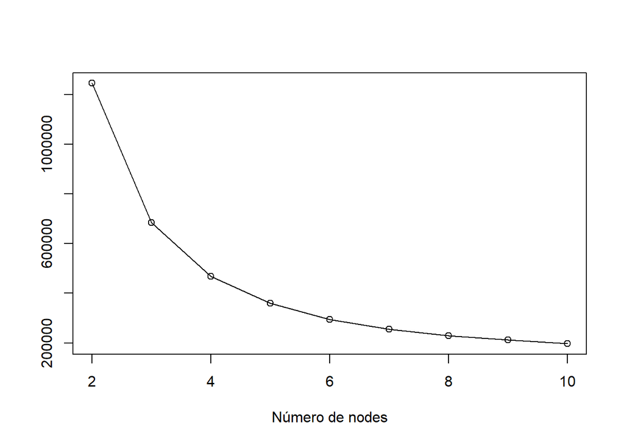

```r
j <- 10

res <- rep(0,j-1)
clusters <- 2:j


for (i in clusters) {
  fit <- kmeans(MeansSpotify,i)
  res[i] <- fit$tot.withinss
}

plot(2:j, res[2:j], type = "o", xlab = "Número de nodes", ylab="")
```

```r
if (!require('fpc')) install.packages('fpc'); library('fpc')
```

```r
j <- 10

fit_ch <- kmeansruns(MeansSpotify, krange = 1:j, criterion = "ch")
fit_ch$bestk
```

```
## [1] 5
```

Com podem comprovar, el temps de computació és molt elevat pel criteri de Calinski-Harabasz i, com que la quantitat de dades és molt elevada, també ho és pel criteri de la silueta mitja.

```r
#fit_asw <- kmeansruns(MeansSpotify, krange = 1:j, criterion = "asw")
#fit_asw$bestk
```

#### 1.3.2.2 Representació gràfica

De manera que ja sabem que hem d’aplicar kmeans amb 5 nodes. Veiem la representació gràfica d’aquests nodes i comparem-lo amb la popularitat:

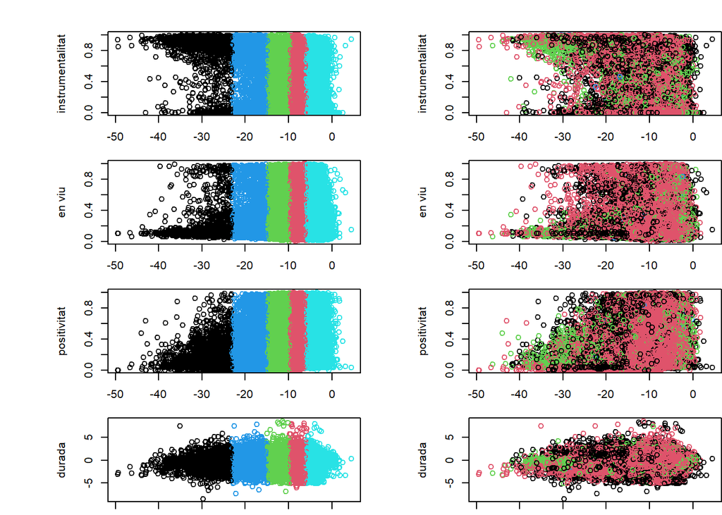

```r
Spotify5nod <- kmeans(MeansSpotify,5)

par(mfrow=c(4,2), plt = c(0.3,1,0.1,0.75))

plot(MeansSpotify[c(1,2)], col=Spotify5nod$cluster, main= "",xlab="soroll", ylab="instrumentalitat")
plot(Spotifynew[c(5,7)], col=Spotifynew$popularity4, main= "",xlab="soroll", ylab="instrumentalitat")

plot(MeansSpotify[c(1,3)], col=Spotify5nod$cluster, main= "",xlab="soroll", ylab="en viu")
plot(Spotifynew[c(5,8)], col=Spotifynew$popularity4, main= "",xlab="soroll", ylab="en viu")

plot(MeansSpotify[c(1,4)], col=Spotify5nod$cluster, main= "",xlab="soroll", ylab="positivitat")
plot(Spotifynew[c(5,9)], col=Spotifynew$popularity4, main= "",xlab="soroll", ylab="positivitat")

plot(MeansSpotify[c(1,5)], col=Spotify5nod$cluster, main= "",xlab="soroll", ylab="durada")
plot(Spotifynew[c(5,12)], col=Spotifynew$popularity4, main= "",xlab="soroll", ylab="durada")
```

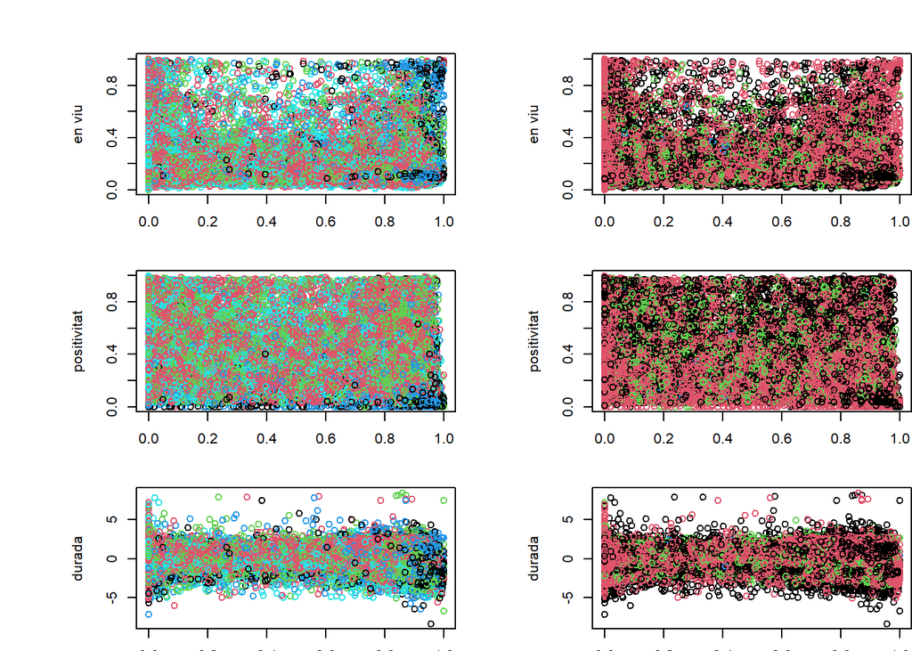

```r
par(mfrow=c(3,2), plt = c(0.3,1,0.1,0.75))

plot(MeansSpotify[c(2,3)], col=Spotify5nod$cluster, main= "",xlab="instrumentalitat", ylab="en viu")
plot(Spotifynew[c(7,8)], col=Spotifynew$popularity4, main= "",xlab="instrumentalitat", ylab="en viu")

plot(MeansSpotify[c(2,4)], col=Spotify5nod$cluster, main= "",xlab="instrumentalitat", ylab="positivitat")
plot(Spotifynew[c(7,9)], col=Spotifynew$popularity4, main= "",xlab="instrumentalitat", ylab="positivitat")

plot(MeansSpotify[c(2,5)], col=Spotify5nod$cluster, main= "",xlab="instrumentalitat", ylab="durada")
plot(Spotifynew[c(7,12)], col=Spotifynew$popularity4, main= "",xlab="instrumentalitat", ylab="durada")
```

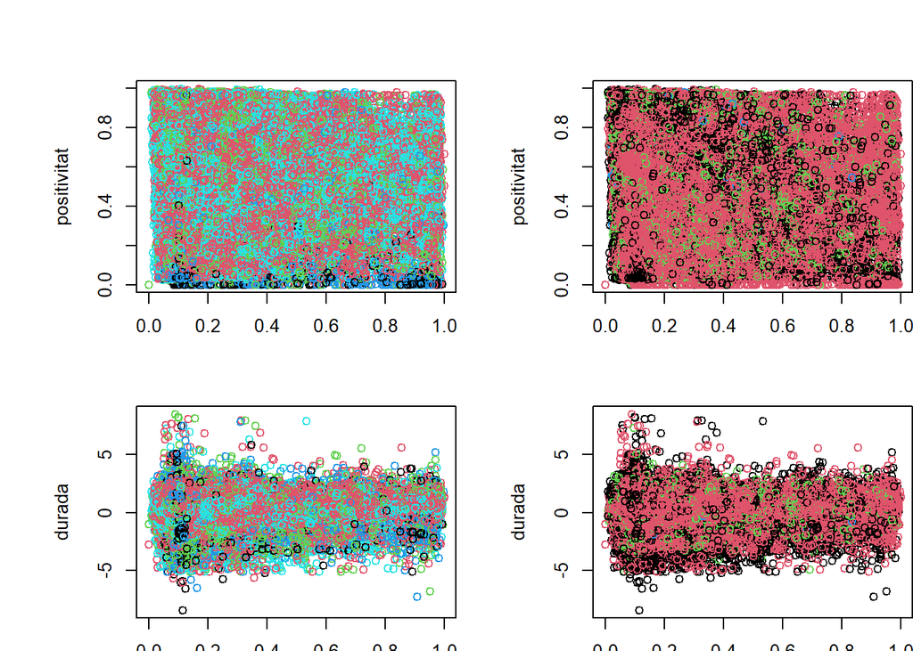

```r
par(mfrow=c(2,2), plt = c(0.3,1,0.1,0.75))

plot(MeansSpotify[c(3,4)], col=Spotify5nod$cluster, main= "",xlab="en viu", ylab="positivitat")
plot(Spotifynew[c(8,9)], col=Spotifynew$popularity4, main= "",xlab="en viu", ylab="positivitat")

plot(MeansSpotify[c(3,5)], col=Spotify5nod$cluster, main= "",xlab="en viu", ylab="durada")
plot(Spotifynew[c(8,12)], col=Spotifynew$popularity4, main= "",xlab="en viu", ylab="durada")
```

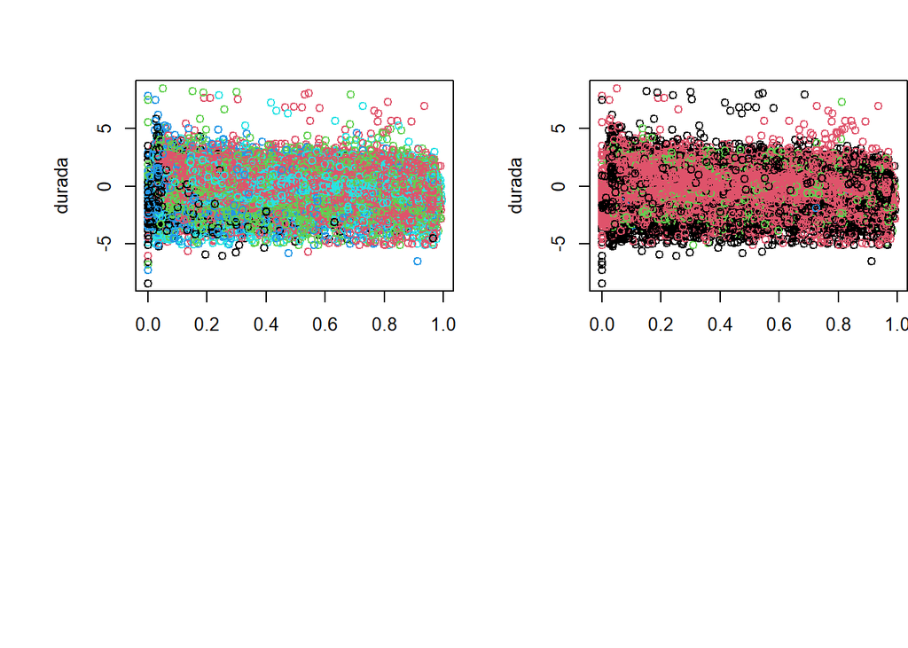

```r
par(mfrow=c(2,2), plt = c(0.3,1,0.1,0.75))

plot(MeansSpotify[c(4,5)], col=Spotify5nod$cluster, main= "",xlab="positivitat", ylab="durada")
plot(Spotifynew[c(9,12)], col=Spotifynew$popularity4, main= "",xlab="positivitat", ylab="durada")
```

A primera vista, sembla que no hi ha cap paràmetre que pugui predir la popularitat d’una cançó en general. A més, la gran quantitat de dades que tenim fa que la lectura dels gràfics sigui molt complicada.

De totes maneres, pensem que la música és molt diferent i que potser el que si que podem trobar són paràmetres que fan que una cançó dins d’un gènere sigui popular.

Ara la pregunta que tenim és: Quin gènere hem de triar per aquest estudi?

### 1.3.3 Selecció de gènere

La idea és prendre un gènere que tingui una bona proporció de cançons populars i una bona proporció de cançons no populars:

```r
proppop <- round(
  prop.table(
    table(Spotify$track_genre,Spotify$popularity4),
    margin = 1),
  digits = 2)

head(proppop[order(proppop[,"(75,100]"],decreasing=TRUE),])
```

```
##
##           [0,25] (25,50] (50,75] (75,100]
##   dance     0.71    0.00    0.11     0.18
##   pop       0.34    0.01    0.46     0.18
##   rock      0.75    0.02    0.07     0.16
##   indie     0.35    0.24    0.30     0.12
##   latino    0.59    0.17    0.12     0.12
##   electro   0.47    0.03    0.39     0.10
```

Triarem el dance, donat que és el primer de la llista. És cert que no té representació en el tram (25,50] però no hauria de suposar cap problema.

Ara crearem una mostra d’entre les cançons dance i obtenim el següent subconjunt de dades:

```r
library(dplyr)

Dance <- subset(Spotifynew, track_genre=="dance")

Dance1 <- Dance %>%
  filter(popularity4=="(75,100]") %>%
  sample_n(100,replace = FALSE)

Dance2 <- Dance %>%
  filter(popularity4=="(50,75]") %>%
  sample_n(100,replace = FALSE)

Dance3 <- Dance %>%
  filter(popularity4=="(25,50]") %>%
  sample_n(2,replace = FALSE)

Dance4 <- Dance %>%
  filter(popularity4=="[0,25]") %>%
  sample_n(100,replace = FALSE)

Dance <- bind_rows(Dance1,Dance2,Dance3,Dance4)
MeansDance <- Dance[,-c(1,2,3,4,6,10,11,13)]
```

Veiem si té sentit buscar nodes que separin les dades:

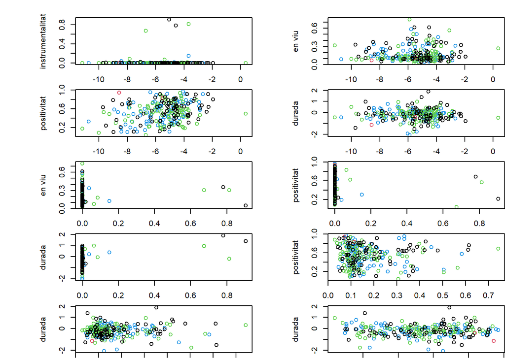

```r
par(mfrow=c(5,2), plt = c(0.3,1,0.1,0.75))

plot(Dance[c(5,7)], col=Dance$popularity4, main= "",xlab="soroll", ylab="instrumentalitat")

plot(Dance[c(5,8)], col=Dance$popularity4, main= "",xlab="soroll", ylab="en viu")

plot(Dance[c(5,9)], col=Dance$popularity4, main= "",xlab="soroll", ylab="positivitat")

plot(Dance[c(5,12)], col=Dance$popularity4, main= "",xlab="soroll", ylab="durada")

plot(Dance[c(7,8)], col=Dance$popularity4, main= "",xlab="instrumentalitat", ylab="en viu")

plot(Dance[c(7,9)], col=Dance$popularity4, main= "",xlab="instrumentalitat", ylab="positivitat")

plot(Dance[c(7,12)], col=Dance$popularity4, main= "",xlab="instrumentalitat", ylab="durada")

plot(Dance[c(8,9)], col=Dance$popularity4, main= "",xlab="en viu", ylab="positivitat")

plot(Dance[c(8,12)], col=Dance$popularity4, main= "",xlab="en viu", ylab="durada")

plot(Dance[c(9,12)], col=Dance$popularity4, main= "",xlab="positivitat", ylab="durada")
```

No té cap sentit perquè els paràmetres de les cançons estan massa entrellaçats. Però si que és interessant veure com les cançons no són instrumentals.

De tota manera, no és el que buscàvem. El que farem és trobar un gènere amb regles més estrictes, donat que el Dance té massa variabilitat. I el gènere més formal és la música clàssica:

```r
Classic <- subset(Spotifynew, track_genre=="classical")

Classic2 <- Classic %>%
  filter(popularity4=="(50,75]") %>%
  sample_n(55,replace = FALSE)

Classic3 <- Classic %>%
  filter(popularity4=="(25,50]") %>%
  sample_n(100,replace = FALSE)

Classic4 <- Classic %>%
  filter(popularity4=="[0,25]") %>%
  sample_n(100,replace = FALSE)

Classic <- bind_rows(Classic2,Classic3,Classic4)
MeansClassic <- Classic[,-c(1,2,3,4,6,10,11,13)]
```

Veiem si podem aplicar-li un k-means:

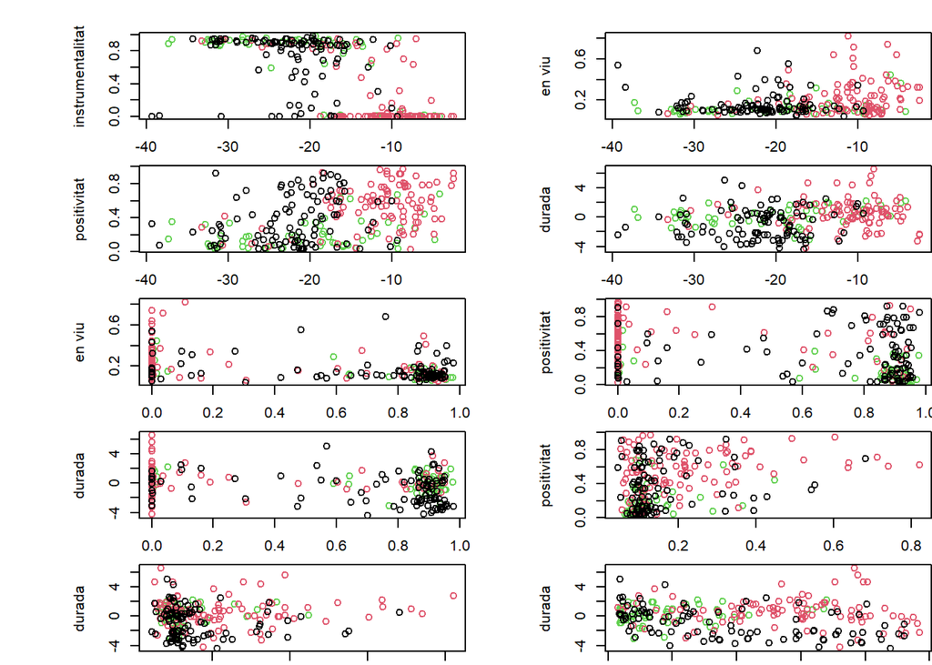

```r
par(mfrow=c(5,2), plt = c(0.3,1,0.1,0.75))

plot(Classic[c(5,7)], col=Classic$popularity4, main= "",xlab="soroll", ylab="instrumentalitat")

plot(Classic[c(5,8)], col=Classic$popularity4, main= "",xlab="soroll", ylab="en viu")

plot(Classic[c(5,9)], col=Classic$popularity4, main= "",xlab="soroll", ylab="positivitat")

plot(Classic[c(5,12)], col=Classic$popularity4, main= "",xlab="soroll", ylab="durada")

plot(Classic[c(7,8)], col=Classic$popularity4, main= "",xlab="instrumentalitat", ylab="en viu")

plot(Classic[c(7,9)], col=Classic$popularity4, main= "",xlab="instrumentalitat", ylab="positivitat")

plot(Classic[c(7,12)], col=Classic$popularity4, main= "",xlab="instrumentalitat", ylab="durada")

plot(Classic[c(8,9)], col=Classic$popularity4, main= "",xlab="en viu", ylab="positivitat")

plot(Classic[c(8,12)], col=Classic$popularity4, main= "",xlab="en viu", ylab="durada")

plot(Classic[c(9,12)], col=Classic$popularity4, main= "",xlab="positivitat", ylab="durada")
```

Observem que aquí si que obtenim gràfics susceptibles per a aplicar-li k-means. Exemples d’aquests són instrumentalitat i soroll, positivitat i soroll, durada i soroll, positivitat i instrumentalitat i durada i positivitat. Aquests seran els gràfics que mirarem i les variables implicades les que utilitzarem per aplicar k-means:

### 1.3.4 K-means a la música clàssica

```r
MeansClassic <- MeansClassic[,-3]
names(MeansClassic)
```

```
## [1] "loudness"         "instrumentalness" "valence"          "durationscale"
```

#### 1.3.4.1 Elecció de nodes

Comencem per l’elecció de nodes.

Com abans, primer veurem el criteri de la silueta:

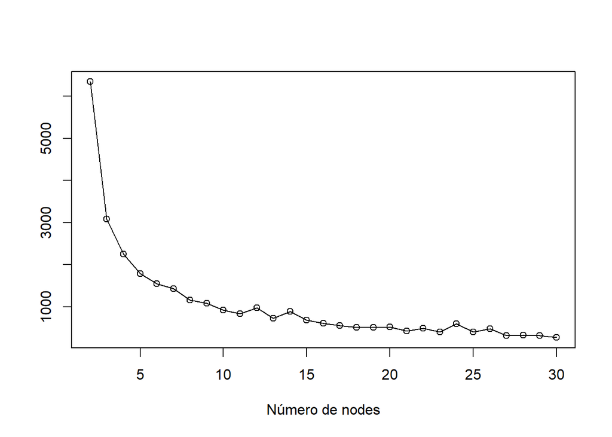

```r
j <- 30

res <- rep(0,j-1)
clusters <- 2:j


for (i in clusters) {
  fit <- kmeans(MeansClassic,i)
  res[i] <- fit$tot.withinss
}

plot(2:j, res[2:j], type = "o", xlab = "Número de nodes", ylab="")
```

Sembla que 2 o 3 és el número de nodes més correcte segons aquest criteri.

Seguim amb la funció kmeansruns i els dos criteris que hem intentat utilitzar pel total de les dades:

```r
j <- 20

fit_ch <- kmeansruns(MeansClassic, krange = 1:j, criterion = "ch")
fit_ch$bestk
```

```
## [1] 3
```

```r
fit_asw <- kmeansruns(MeansClassic, krange = 1:j, criterion = "asw")
fit_asw$bestk
```

```
## [1] 3
```

Per tant, obtenim dues possibilitats: 2 o 3 nodes. Veiem si gràficament obtenim quin és el nombre òptim de nodes.

#### 1.3.4.2 Representació gràfica

Comencem amb 2 nodes:

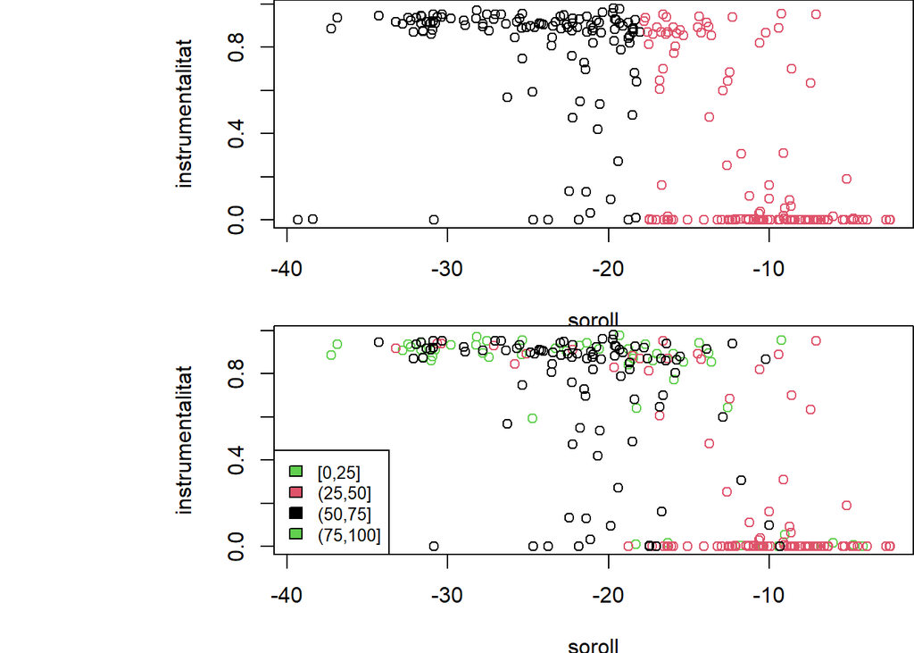

```r
Classic2nod <- kmeans(MeansClassic,2)

par(mfrow=c(2,1), plt = c(0.3,1,0.3,1))

plot(MeansClassic[c(1,2)], col=Classic2nod$cluster, main= "",xlab="soroll", ylab="instrumentalitat")
plot(Classic[c(5,7)], col=Classic$popularity4, main= "",xlab="soroll", ylab="instrumentalitat")
legend("bottomleft", legend = levels(Classic$popularity4), fill = unique(Classic$popularity4), cex = 0.8)
```

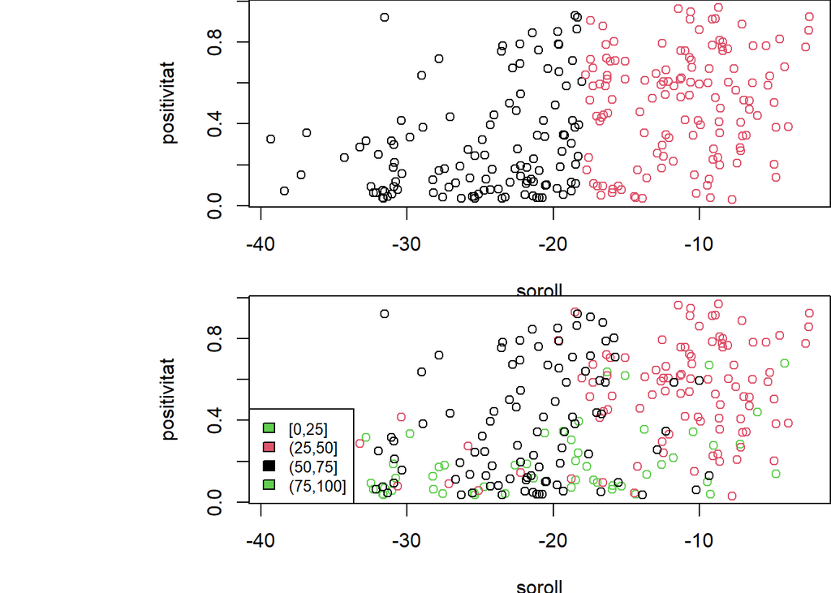

```r
par(mfrow=c(2,1), plt = c(0.3,1,0.3,1))

plot(MeansClassic[c(1,3)], col=Classic2nod$cluster, main= "",xlab="soroll", ylab="positivitat")
plot(Classic[c(5,9)], col=Classic$popularity4, main= "",xlab="soroll", ylab="positivitat")
legend("bottomleft", legend = levels(Classic$popularity4), fill = unique(Classic$popularity4), cex = 0.8)
```

Aquest gràfic sembla que separa correctament en dos nodes el tram (25,50] de la resta de trams. Tot i que podem veure que quan el soroll està entre -20 i -10 i la positivitat entre 0 i 0.4 el node negre falla prou a l’hora de classificar. Però podem afirmar que si una cançó de música clàssica és molt sorollosa i positiva tendirà a ser mediocre. Això vol dir que no serà un èxit però que tampoc tindrà una popularitat molt baixa.

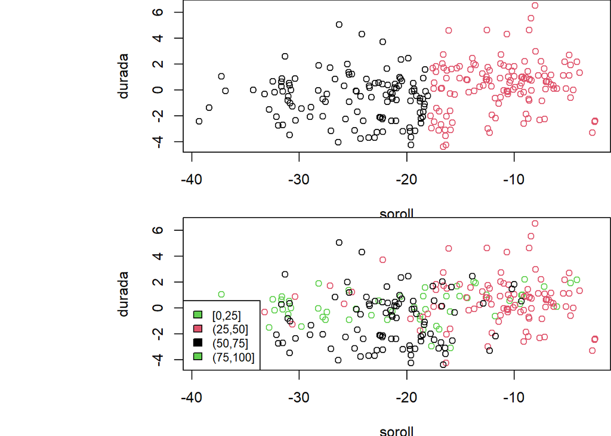

```r
par(mfrow=c(2,1), plt = c(0.3,1,0.3,1))

plot(MeansClassic[c(1,4)], col=Classic2nod$cluster, main= "",xlab="soroll", ylab="durada")
plot(Classic[c(5,12)], col=Classic$popularity4, main= "",xlab="soroll", ylab="durada")
legend("bottomleft", legend = levels(Classic$popularity4), fill = unique(Classic$popularity4), cex = 0.8)
```

Aquest gràfic si que té dos nodes molt ben ajustats. I ens confirmen que si una cançó de música clàssica és molt sorollosa, tendirà a una popularitat no destacable.

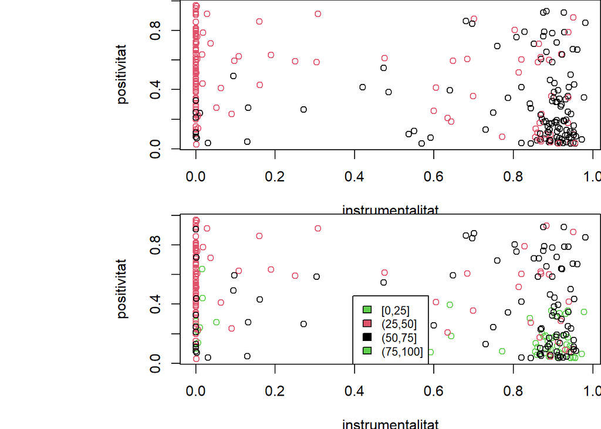

```r
par(mfrow=c(2,1), plt = c(0.3,1,0.3,1))

plot(MeansClassic[c(2,3)], col=Classic2nod$cluster, main= "",xlab="instrumentalitat", ylab="positivitat")
plot(Classic[c(7,9)], col=Classic$popularity4, main= "",xlab="instrumentalitat", ylab="positivitat")
legend("bottom", legend = levels(Classic$popularity4), fill = unique(Classic$popularity4), cex = 0.8)
```

Ajusta bé, però perdem informació que amb algun altre mètode potser recollim, donat que ens agrupa els trams (0,25] amb el tram (50,75]. Tot i així, podem afirmar que les cançons de música clàssica sense intrumentalitat també tenen una popularitat mediocre.

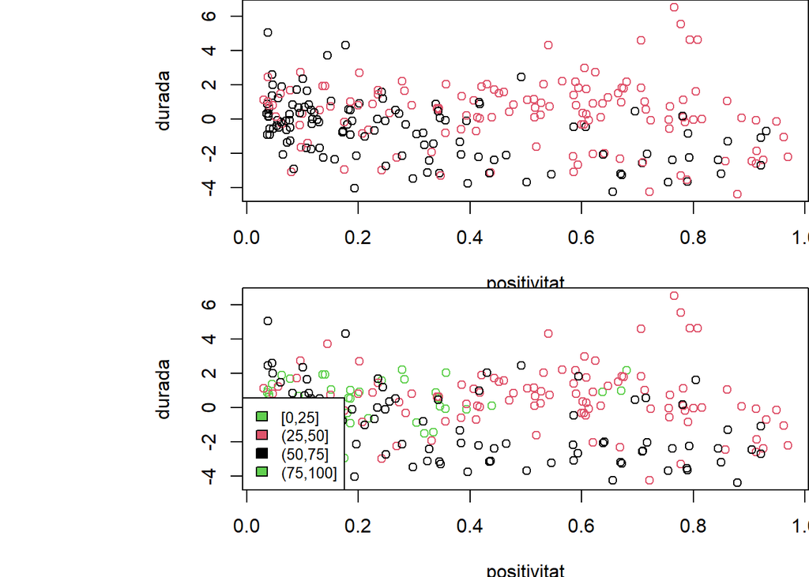

```r
par(mfrow=c(2,1), plt = c(0.3,1,0.3,1))

plot(MeansClassic[c(3,4)], col=Classic2nod$cluster, main= "",xlab="positivitat", ylab="durada")
plot(Classic[c(9,12)], col=Classic$popularity4, main= "",xlab="positivitat", ylab="durada")
legend("bottomleft", legend = levels(Classic$popularity4), fill = unique(Classic$popularity4), cex = 0.8)
```

Aquesta agrupació de les dades ens torna a separar el tram (25,50] de la resta de trams i ens fa deduir que les cançons de música clàssica que més durada tenen són les que tendeixen a tenir una popularitat mediocre.

Com que els resultats amb dos nodes han estat bons però millorables dividirem les dades en 3 nodes:

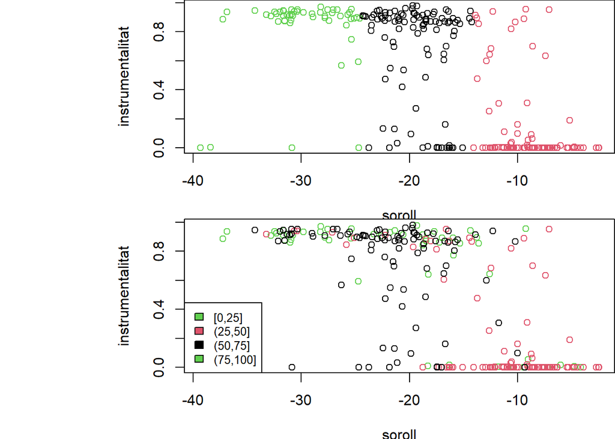

```r
Classic4nod <- kmeans(MeansClassic,3)

par(mfrow=c(2,1), plt = c(0.3,1,0.3,1))

plot(MeansClassic[c(1,2)], col=Classic4nod$cluster, main= "",xlab="soroll", ylab="instrumentalitat")
plot(Classic[c(5,7)], col=Classic$popularity4, main= "",xlab="soroll", ylab="instrumentalitat")
legend("bottomleft", legend = levels(Classic$popularity4), fill = unique(Classic$popularity4), cex = 0.8)
```

No sembla que ajusti gaire bé els trams de popularitat a part del (25,50]. Haurem d’utilitzar un canvi de mètrica o bé un model Optics o dbscan.

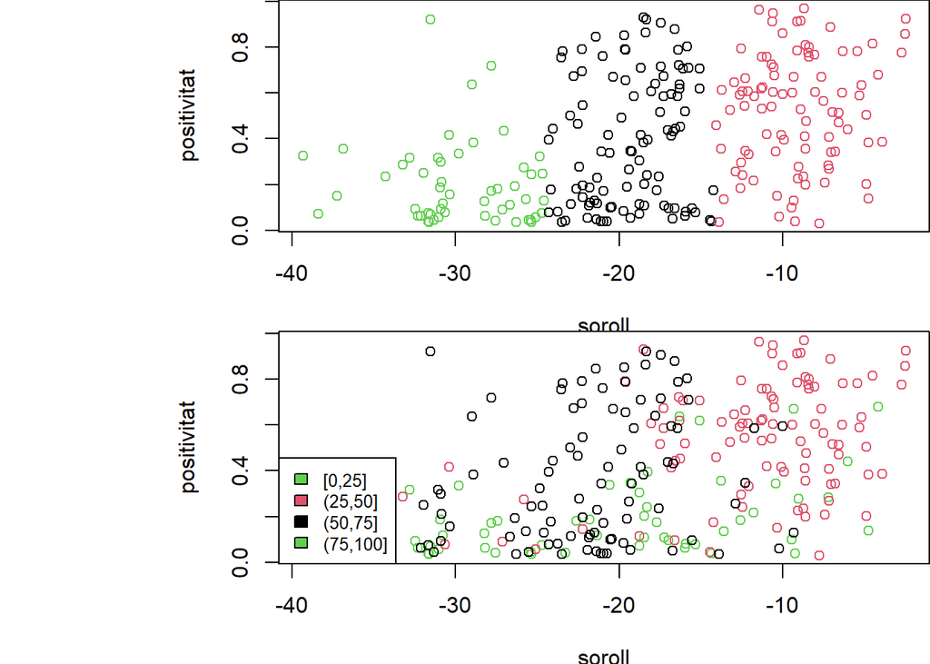

```r
par(mfrow=c(2,1), plt = c(0.3,1,0.3,1))

plot(MeansClassic[c(1,3)], col=Classic4nod$cluster, main= "",xlab="soroll", ylab="positivitat")
plot(Classic[c(5,9)], col=Classic$popularity4, main= "",xlab="soroll", ylab="positivitat")
legend("bottomleft", legend = levels(Classic$popularity4), fill = unique(Classic$popularity4), cex = 0.8)
```

Aquí ocorre el mateix que en el primer gràfic. Si que és cert que el tram (25,50] està correctament agrupat però els altres dos no tenim una bona feina.

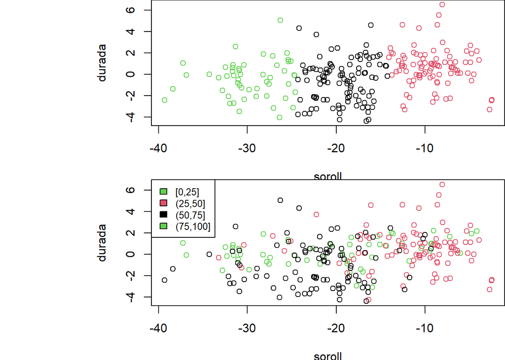

```r
par(mfrow=c(2,1), plt = c(0.3,1,0.3,1))

plot(MeansClassic[c(1,4)], col=Classic4nod$cluster, main= "",xlab="soroll", ylab="durada")
plot(Classic[c(5,12)], col=Classic$popularity4, main= "",xlab="soroll", ylab="durada")
legend("topleft", legend = levels(Classic$popularity4), fill = unique(Classic$popularity4), cex = 0.8)
```

El mateix problema que en l’anterior gràfic.

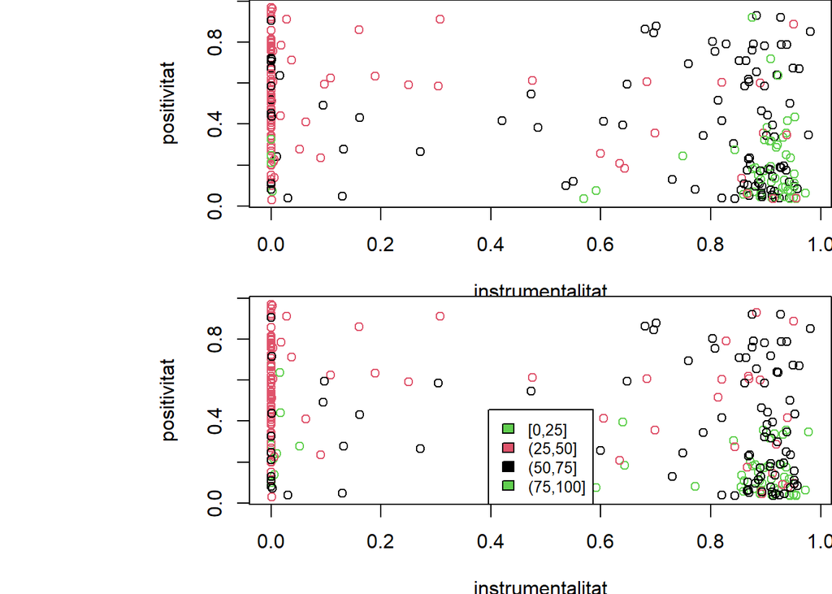

```r
par(mfrow=c(2,1), plt = c(0.3,1,0.3,1))

plot(MeansClassic[c(2,3)], col=Classic4nod$cluster, main= "",xlab="instrumentalitat", ylab="positivitat")
plot(Classic[c(7,9)], col=Classic$popularity4, main= "",xlab="instrumentalitat", ylab="positivitat")
legend("bottom", legend = levels(Classic$popularity4), fill = unique(Classic$popularity4), cex = 0.8)
```

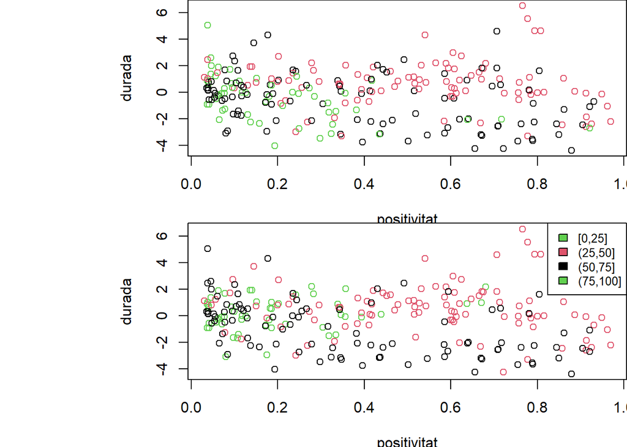

```r
par(mfrow=c(2,1), plt = c(0.3,1,0.3,1))

plot(MeansClassic[c(3,4)], col=Classic4nod$cluster, main= "",xlab="positivitat", ylab="durada")
plot(Classic[c(9,12)], col=Classic$popularity4, main= "",xlab="positivitat", ylab="durada")
legend("topright", legend = levels(Classic$popularity4), fill = unique(Classic$popularity4), cex = 0.8)
```

Per aquest gràfic també hauríem de considerar aplicar un canvi de mètrica o un model Optics/dbscan.

#### 1.3.4.3 Conclusions

Les conclusions d’aquest estudi són que 2 nodes és la millor manera d’aplicar k-means a aquest conjunt de dades en particular. Tot i així, hem de continuar l’estudi amb altres mètodes ja que amb dos nodes perdem prou informació.

El que si és cert és que podem extreure informació del tram (25,50].

Una cançó del gènere de música clàssica tendirà a tenir una popularitat de (25,50] si:

- És sorollosa i positiva.
- És molt sorollosa.
- No té instrumentalitat.
- Té una llarga durada.

### 1.3.5 Canvi de mètrica al model K-means

Una de les opcions per a que la funció k-means ens ajusti millor els clusters és canviant la distància utilitzada. Normalment s’utilitza la distància euclidiana però en tenim més: Manhattan, Minkowski, la distància del cosinus o Jaccard en són alguns exemples.

Com que no ens trobem en cap tipus de graella no té sentit utilitzar manhattan. D’altra banda, no tenim una quantitat de dades tan gran com per utilitzar la distància del cosinus i les variables són numèriques i no categòriques per utilitzar la distància de Jaccard. Potser podríem intentar aplicar la mesura de Minkowski amb un p adequat però hauríem de fer un estudi extens per a triar el número p òptim que ens prendria molt de temps.

La nostra idea serà utilitzar el mètode del màxim:

```r
install.packages("amap", repos='http://cran.us.r-project.org')
library(amap)
```

```r
j <- 15

res <- rep(0,j-1)
clusters <- 2:j


for (i in clusters) {
  fit <- Kmeans(MeansClassic, i, iter.max = 20, method = "maximum")
  res[i] <- sum(fit$withinss)
}
```

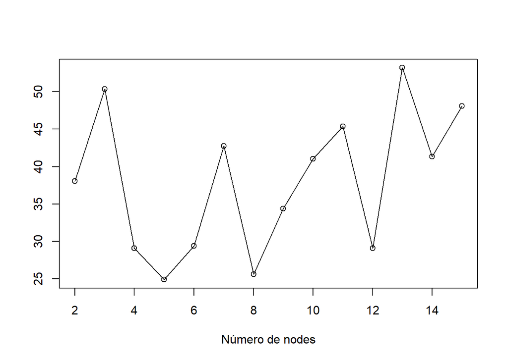

```r
plot(2:j, res[2:j], type = "o", xlab = "Número de nodes", ylab="")
```

Si que és cert que en la resta de K-means hem aplicat més criteris a part de l’anterior. Ara bé, tot i que no sembla que tinguem una convergència en el número de nodes, el que volem fer canviant la distància és una millora respecte la classificació amb tres nodes. I, amb aquest criteri, podria millorar aquesta agrupació. Per tant:

```r
MaxClassic3nod <- Kmeans(MeansClassic, 3, method = "maximum")
```